# Sentiment Analysis on Twitter Data

## Step 7 - Building and Testing the Model

Now that we have our data split into training and test sets, we can use the Naive Bayes Classiier to build our model. We can also gauge the accuracy of the model using the `accuracy` method on the resulting model. The accuracy of the model is based on the percentage of tweets for which the model correctly predicted the sentiment. Let's run it and see what we get!

```python
classifier = NaiveBayesClassifier.train(train_data)

print("Accuracy is:", classify.accuracy(classifier, test_data))
print(classifier.show_most_informative_features(10))
```

```
Accuracy is: 0.9935
Most Informative Features
                      :( = True           Negati : Positi =    587.0 : 1.0
                      :) = True           Positi : Negati =    474.1 : 1.0
                   great = True           Positi : Negati =     16.7 : 1.0
                  friday = True           Positi : Negati =     14.4 : 1.0
                   sorry = True           Negati : Positi =     12.1 : 1.0
                    miss = True           Negati : Positi =     10.0 : 1.0
                   enjoy = True           Positi : Negati =      9.7 : 1.0
                    hate = True           Negati : Positi =      9.6 : 1.0
                   thank = True           Positi : Negati =      9.1 : 1.0
                   can't = True           Negati : Positi =      8.6 : 1.0
None
```

Wow! The model has a 99.4% accuracy when it comes to predicting the sentiment! The informative features shows the ratio of positive and negative tweets associated with each token. The :) and :( emojis as we saw before were the most frequently occurring tokens. The :) emoji had a positive to negative ratio of 474.1:1 which means that for every 475 tweets that have this emoji in it, 474 of them are expected to have a positive sentiment. On the other hand the :( emoji has a negative to positive ratio of 587:1 which means that our of every 588 tweets containing this emoji, 587 are expected to have a negative sentiment.

Now I can easily test the performance of this model using any random phrases. I generated these 4 sentences using a random sentence generator I found online here: https://randomwordgenerator.com/sentence.php

```python
custom_tweet = "They did nothing as the raccoon attacked the lady’s bag of food.\
                After coating myself in vegetable oil I found my success rate skyrocketed. \
                The beach was crowded with snow leopards.\
                Lets all be unique together until we realise we are all the same."

custom_tokens = remove_noise(word_tokenize(custom_tweet))
print(custom_tokens)
print(classifier.classify(dict([token, True] for token in custom_tokens)))
```

```
['they', 'do', 'nothing', 'as', 'the', 'raccoon', 'attack', 'the', 'lady', '’', 's', 'bag', 'of', 'food', 'after', 'coat', 'myself', 'in', 'vegetable', 'oil', 'i', 'find', 'my', 'success', 'rate', 'skyrocket', 'the', 'beach', 'be', 'crowd', 'with', 'snow', 'leopard', 'lets', 'all', 'be', 'unique', '…
Negative
```

The classifier determined that the overall sentiment of these 4 sentences is Negative. Which I agree with. I don't think I'd be too happy with either of those randomly posited scenarios lol

## Visualizing the Data

Now that we have our data cleaned up and a working model let's visualize some things! First, I'll make a wordcloud for each of the positive and negative dataset as shown below. I'll apply a twitter logo mask to it because it seems appropriate given the context.

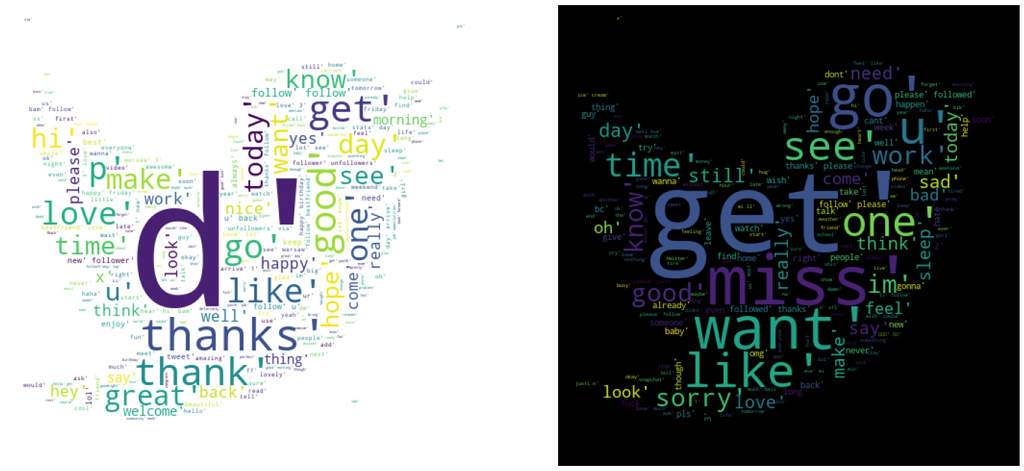

```python
from wordcloud import WordCloud, STOPWORDS, ImageColorGenerator
import matplotlib.pyplot as plt
import numpy as np
from PIL import Image

twitter_mask = np.array(Image.open("twitter logo.png"))

# generate the word cloud for the positive tweets
posWC = WordCloud(
                          max_words=2000,
                          mask = twitter_mask,
                          contour_width=0,
                          max_font_size=500,
                          font_step=2,
                          background_color='white',
                          width=550,
                          height=550
                          ).generate(str(positive_cleaned_tokens_list))

# generate the word cloud for the negative tweets
negWC = WordCloud(
                          max_words=2000,
                          mask = twitter_mask,
                          contour_width=0,
                          max_font_size=500,
                          font_step=2,
                          background_color='black',
                          width=550,
                          height=550
                          ).generate(str(negative_cleaned_tokens_list))

fig,axs = plt.subplots(1,2, figsize=(25,30))
axs[0].axis("off")
axs[1].axis("off")
axs[0].imshow(posWC)
axs[1].imshow(negWC)
plt.show()
```

Neat!! I'll definitely have fun playing with these more in the future!

## Using VADER for Polarity Scores

VADER ( Valence Aware Dictionary for Sentiment Reasoning) is a model used for sentiment analysis of text. It is sensitive to positive and negative emotions (also referred to as polarity) as well as the intensity or strength of emotion.

VADER relies on a dictionary that maps lexical features to emotion intensities which are known as sentiment scores or polarity scores. The sentiment score is obtained by summing up the intensity of each word in the piece of text one is documenting. Therefore, we can use VADER to determine whether a sentence, a paragraph, a tweet, or even a whole document has a particular sentiment. So long as your data is in string format you are good to go.

I'll start by generating an instance of VADER as shown below

```python
sid = SentimentIntensityAnalyzer()
```

We can now use this analyzer on any text data we want. Next, I'll import the pandas library to place all of the tweets we used before into a dataframe. I'm doing this because then I can readily apply the polarity calculations to each tweet in a clean and efficient way. I will then loop over each of the positive tweets that we denoised earlier and use the `join` method to convert each tweet from a comma separated list into a string that is readily parsable by VADER. I'll do the same for the denoised negative tweets.

```python
import pandas as pd

pos_tweets_list = []
for i in range(len(positive_cleaned_tokens_list)):
    tweet = ' '.join(positive_cleaned_tokens_list[i])
    pos_tweets_list.append(tweet)

df_pos = pd.DataFrame(pos_tweets_list,columns=['positive_tweets'])
df_pos
```

|  | positive_tweets |
| --- | --- |
| 0 | #followfriday top engage member community week :) |
| 1 | hey james odd :/ please call contact centre 02... |
| 2 | listen last night :) bleed amazing track scotland |
| 3 | congrats :) |
| 4 | yeaaaah yippppy accnt verify rqst succeed get ... |
| ... | ... |
| 4995 | chris that's great hear :) due time reminder i... |
| 4996 | thanks shout-out :) great aboard |
| 4997 | hey :) long time talk ... |
| 4998 | matt would say welcome adulthood ... :) |
| 4999 | could say egg face :-) |

5000 rows × 1 columns

And the same thing for the negative tweets

```python
neg_tweets_list = []
for i in range(len(negative_cleaned_tokens_list)):
    tweet = ' '.join(negative_cleaned_tokens_list[i])
    neg_tweets_list.append(tweet)

df_neg = pd.DataFrame(neg_tweets_list,columns=['negative_tweets'])
df_neg
```

|  | negative_tweets |
| --- | --- |
| 0 | hopeless tmr :( |
| 1 | everything kid section ikea cute shame i'm nea... |
| 2 | heart slide waste basket :( |
| 3 | “ hate japanese call ban :( :( ” |
| 4 | dang start next week work :( |
| ... | ... |
| 4995 | wanna change avi usanele :( |
| 4996 | puppy broke foot :( |
| 4997 | where's jaebum baby picture :( |
| 4998 | mr ahmad maslan cook :( |
| 4999 | hull supporter expect misserable week :-( |

5000 rows × 1 columns

Now we can apply the polarity scores onto each tweet in each of our dataframes and generate columns that contain the positive, neutral, negative, and compound polarity score for each tweet which I also visualize in histograms below

```python
df_pos['compound'] = [sid.polarity_scores(x)['compound'] for x in df_pos['positive_tweets']]
df_pos['neg']      = [sid.polarity_scores(x)['neg'] for x in      df_pos['positive_tweets']]
df_pos['neu']      = [sid.polarity_scores(x)['neu'] for x in      df_pos['positive_tweets']]
df_pos['pos']      = [sid.polarity_scores(x)['pos'] for x in      df_pos['positive_tweets']]
df_pos
```

|  | positive_tweets | compound | neg | neu | pos |
| --- | --- | --- | --- | --- | --- |
| 0 | #followfriday top engage member community week :) | 0.7351 | 0.000 | 0.357 | 0.643 |
| 1 | hey james odd :/ please call contact centre 02... | 0.5423 | 0.215 | 0.411 | 0.374 |
| 2 | listen last night :) bleed amazing track scotland | 0.7783 | 0.000 | 0.469 | 0.531 |
| 3 | congrats :) | 0.7506 | 0.000 | 0.000 | 1.000 |
| 4 | yeaaaah yippppy accnt verify rqst succeed get ... | 0.7351 | 0.000 | 0.677 | 0.323 |
| ... | ... | ... | ... | ... | ... |
| 4995 | chris that's great hear :) due time reminder i... | 0.7964 | 0.000 | 0.608 | 0.392 |
| 4996 | thanks shout-out :) great aboard | 0.8779 | 0.000 | 0.083 | 0.917 |
| 4997 | hey :) long time talk ... | 0.4588 | 0.000 | 0.625 | 0.375 |
| 4998 | matt would say welcome adulthood ... :) | 0.7184 | 0.000 | 0.455 | 0.545 |
| 4999 | could say egg face :-) | 0.3182 | 0.000 | 0.635 | 0.365 |

5000 rows × 5 columns

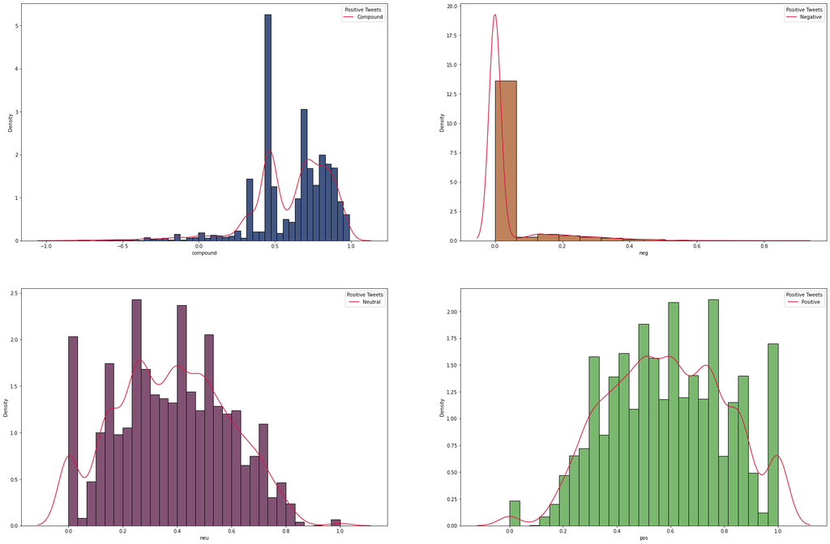

```python
import seaborn as sns
fig,axs = plt.subplots(2,2, figsize = (30,20))
sns.histplot(df_pos['compound'] , ax = axs[0,0], color ='#011d59' , alpha = 0.75, stat='density')
sns.kdeplot(df_pos['compound'], color='crimson', ax=axs[0,0])
axs[0,0].legend(labels=["Compound"], title = "Positive Tweets")

sns.histplot(df_pos['neg']      , ax=axs[0,1] , color ='#a95927' , alpha = 0.75, stat='density')
sns.kdeplot(df_pos['neg'], color='crimson', ax=axs[0,1])
axs[0,1].legend(labels=["Negative"], title = "Positive Tweets")

sns.histplot(df_pos['neu']      , ax=axs[1,0], color ='#581845' , alpha = 0.75, stat='density')
sns.kdeplot(df_pos['neu'], color='crimson', ax=axs[1,0])
axs[1,0].legend(labels=["Neutral"], title = "Positive Tweets")

sns.histplot(df_pos['pos']      , ax=axs[1,1] , color ='#4da13f' , alpha = 0.75, stat='density')
sns.kdeplot(df_pos['pos'], color='crimson', ax=axs[1,1])
axs[1,1].legend(labels=["Positive"], title = "Positive Tweets")

plt.show()
```

```python
df_neg['compound'] = [sid.polarity_scores(x)['compound'] for x in df_neg['negative_tweets']]
df_neg['neg']      = [sid.polarity_scores(x)['neg'] for x in      df_neg['negative_tweets']]
df_neg['neu']      = [sid.polarity_scores(x)['neu'] for x in      df_neg['negative_tweets']]
df_neg['pos']      = [sid.polarity_scores(x)['pos'] for x in      df_neg['negative_tweets']]
df_neg
```

|  | negative_tweets | compound | neg | neu | pos |
| --- | --- | --- | --- | --- | --- |
| 0 | hopeless tmr :( | -0.7096 | 0.855 | 0.145 | 0.000 |
| 1 | everything kid section ikea cute shame i'm nea... | -0.4588 | 0.353 | 0.471 | 0.176 |
| 2 | heart slide waste basket :( | -0.6908 | 0.655 | 0.345 | 0.000 |
| 3 | “ hate japanese call ban :( :( ” | -0.9201 | 0.868 | 0.132 | 0.000 |
| 4 | dang start next week work :( | -0.4404 | 0.367 | 0.633 | 0.000 |
| ... | ... | ... | ... | ... | ... |
| 4995 | wanna change avi usanele :( | -0.4404 | 0.420 | 0.580 | 0.000 |
| 4996 | puppy broke foot :( | -0.6908 | 0.740 | 0.260 | 0.000 |
| 4997 | where's jaebum baby picture :( | -0.4404 | 0.420 | 0.580 | 0.000 |
| 4998 | mr ahmad maslan cook :( | -0.4404 | 0.420 | 0.580 | 0.000 |
| 4999 | hull supporter expect misserable week :-( | -0.1027 | 0.291 | 0.465 | 0.244 |

5000 rows × 5 columns

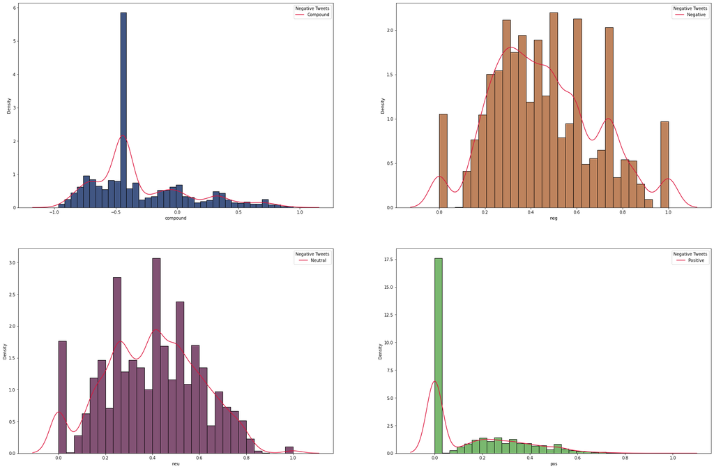

```python
fig,axs = plt.subplots(2,2, figsize = (30,20))

sns.histplot(df_neg['compound'] , ax = axs[0,0], color ='#011d59' , alpha = 0.75, stat='density')
sns.kdeplot(df_neg['compound'], color='crimson', ax=axs[0,0])
axs[0,0].legend(labels=["Compound"], title = "Negative Tweets")

sns.histplot(df_neg['neg']      , ax=axs[0,1] , color ='#a95927' , alpha = 0.75, stat='density')
sns.kdeplot(df_neg['neg'], color='crimson', ax=axs[0,1])
axs[0,1].legend(labels=["Negative"], title = "Negative Tweets")

sns.histplot(df_neg['neu']      , ax=axs[1,0], color ='#581845' , alpha = 0.75, stat='density')
sns.kdeplot(df_neg['neu'], color='crimson', ax=axs[1,0])
axs[1,0].legend(labels=["Neutral"], title = "Negative Tweets")

sns.histplot(df_neg['pos']      , ax=axs[1,1] , color ='#4da13f' , alpha = 0.75, stat='density')
sns.kdeplot(df_neg['pos'], color='crimson', ax=axs[1,1])
axs[1,1].legend(labels=["Positive"], title = "Negative Tweets")

plt.show()
plt.show()
```

## Conclusions

I've shown the necessary steps required to carry out sentiment analysis. Though Twitter data was used for this example, the methods shown here can be readily adapteed to other text formats. I have ideas of projects to try using this so stay tuned!